# Reproducible Research: Peer Assessment 1

Although it would not be part of a final report, I have included the assignment requirements here (in italics) to make reviewing for assessment easier.

## Loading and preprocessing the data

1. *Load the data (i.e. `read.csv()`)*
2. *Process/transform the data (if necessary) into a format suitable for your analysis*

   ```r
   data <- read.csv(unz("activity.zip", "activity.csv"),
                   header=TRUE,
                   colClasses=c("numeric", "Date", "numeric"))
   ```

## What is mean total number of steps taken per day?

For this part of the assignment, you can ignore the missing values in the dataset.

1. *Make a histogram of the total number of steps taken each day*

   The following histogram shows the distribution of the total number of steps per day over the number of days that total was reached.

   I use `na.rm=TRUE` here, so missing measurements are not included as part of the sum, and days without any measurements had a sum of zero.

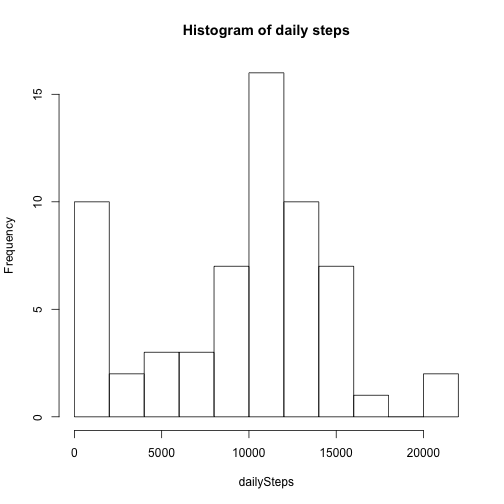

   ```r
   dailySteps <- rowsum(data$steps, data$date, na.rm=TRUE)
   hist(dailySteps, breaks=10, main="Histogram of daily steps")
   ```

   ```r
   meanSteps <- mean(dailySteps)
   medianSteps <- median(dailySteps)
   ```

2. *Calculate and report the* **mean** *and* **median** *total number of steps taken per day*

   Answer: The daily step mean is **9354.2** and the median is **10395.0**. Here they are shown along with the distribution of the total number of steps per day across the whole data set, including the mean and the median:

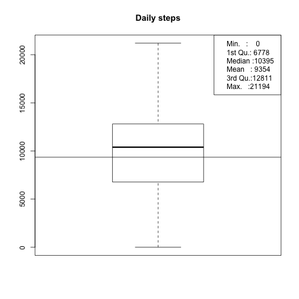

   ```r
   boxplot(dailySteps, main="Daily steps")
   abline(h=meanSteps)
   legend("topright", summary(dailySteps))
   ```

## What is the average daily activity pattern?

1. *Make a time series plot (i.e. `type = "l"`) of the 5-minute interval (x-axis) and the average number of steps taken, averaged across all days (y-axis)*

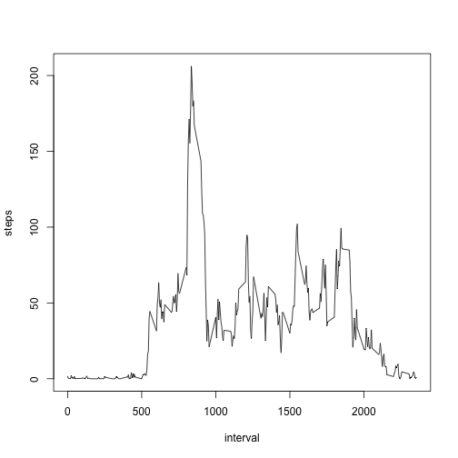

   ```r
   meanStepsByInterval <- aggregate(steps ~ interval, data=data, "mean")
   plot(meanStepsByInterval, type="l")
   ```

2. *Which 5-minute interval, on average across all the days in the dataset, contains the maximum number of steps?*

   ```r
   maxRow <- which.max(meanStepsByInterval$steps)
   maxInterval <- meanStepsByInterval[maxRow,]$interval
   ```

   Answer: Interval **835** has the highest number of steps, averaged across all the days in the dataset.

## Imputing missing values

*Note that there are a number of days/intervals where there are missing values (coded as `NA`). The presence of missing days may introduce bias into some calculations or summaries of the data.*

1. *Calculate and report the total number of missing values in the dataset (i.e. the total number of rows with `NA`s)*

   ```r
   missingRowCount <- sum(!complete.cases(data))
   ```

   Answer: There are **2304** rows with missing values in the dataset.
2. *Devise a strategy for filling in all of the missing values in the dataset. The strategy does not need to be sophisticated. For example, you could use the mean/median for that day, or the mean for that 5-minute interval, etc.*

   I calculate a lookup table for each interval, and create a function which, when given a row, will return either the steps for that row, or the mean (from the lookup table) if the steps are missing from the row.

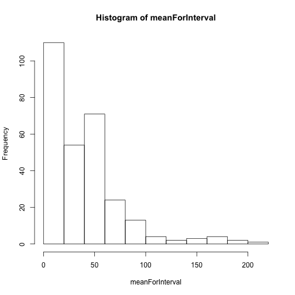

   ```r
   meanForInterval <- tapply(data$steps, data$interval, "mean", na.rm=TRUE)
   hist(meanForInterval)
   ```

   ```r
   library(stringr)
   stepsOrMeanForInterval <- function(row) {
          if (is.na(row[1])) {
                  interval <- str_trim(row[3])
                  meanForInterval[[interval]]
          }
          else {
                  as.numeric(row[1])
          }
   }
   ```

3. *Create a new dataset that is equal to the original dataset but with the missing data filled in.*

   I use the `stepsOrMeanForInterval` function to create a vector of steps for each row in the dataset. The new data set `newdata` uses this vector for its `steps` column.

   ```r
   imputedSteps <- apply(data, 1, stepsOrMeanForInterval)
   newdata <- within(data, { steps <- imputedSteps })
   ```

4. *Make a histogram of the total number of steps taken each day and calculate and report the mean and median total number of steps taken per day. Do these values differ from the estimates from the first part of the assignment? What is the impact of imputing missing data on the estimates of the total daily number of steps?*

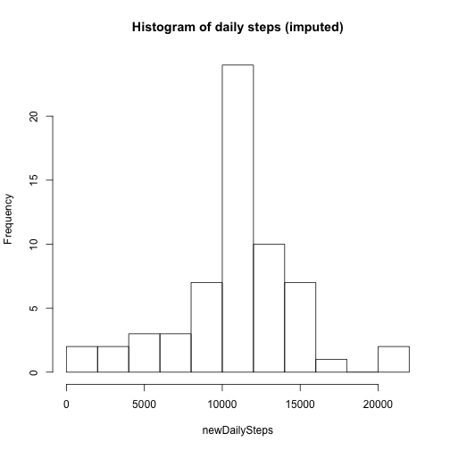

   ```r
   newDailySteps <- rowsum(newdata$steps, newdata$date, na.rm=TRUE)
   hist(newDailySteps, breaks=10, main="Histogram of daily steps (imputed)")
   ```

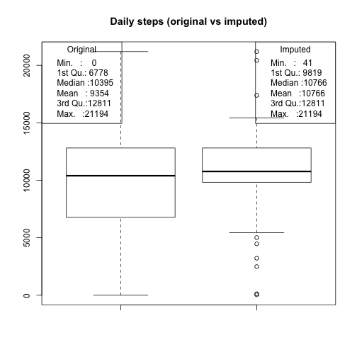

   ```r
   newMeanSteps <- mean(newDailySteps)

   boxplot(dailySteps[,1], newDailySteps[,1],
          main="Daily steps (original vs imputed)")
   legend("topleft", summary(dailySteps), title="Original")
   legend("topright", summary(newDailySteps), title="Imputed")
   ```

   Answer: Do these values differ? The median changes slightly, and the mean increases. From the following boxplot, we can see the imputed values result in a “tight” pattern, with less variance from the mean.

   In the original data set there are eight days which are missing a whole day's data, and imputing values shifts them them to the centre of the distribution.

## Are there differences in activity patterns between weekdays and weekends?

*For this part the `weekdays()` function may be of some help here. Use the dataset with the filled-in missing values for this part.*

1. *Create a new factor variable in the dataset with two levels - “weekday” and “weekend” indicating whether a given date is a weekday or weekend day.*

   ```r
   dayLevels <- c("Monday", "Tuesday", "Wednesday", "Thursday", "Friday",
                 "Saturday", "Sunday")
   data$dayOfWeek <- factor(weekdays(data$date), levels=dayLevels, ordered=TRUE)
   data$dayType <- factor(data$dayOfWeek >= "Monday" & data$dayOfWeek <= "Friday",
                         labels=c("weekend", "weekday"))
   ```

2. *Make a panel plot containing a time series plot (i.e. `type = "l"`) of the 5-minute interval (x-axis) and the average number of steps taken, averaged across all weekday days or weekend days (y-axis). The plot should look something like the following, which was creating using simulated data:*

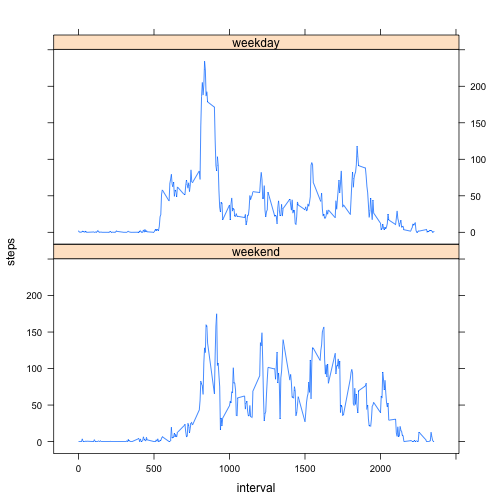

   ```r
   stepsByDayType <- aggregate(steps ~ interval * dayType, data=data, mean)
   xyplot(steps ~ interval | dayType, data=stepsByDayType,
         type="l", layout=c(1,2))
   ```